# 2. 파이썬 표현식과 문장

- 표현식은 실제 실행되어 하나의 값으로 처리하는 구문
- 문장(statements)이란 프로그램 언어에서 특정한 로직을 처리해서 상태를 처리하는 구문
- 보통 표현식을 처리한 후에 문장에 저장해서 처리

```python
from IPython.display import Image
```

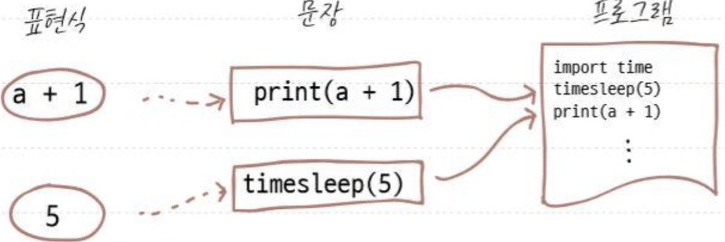

```python
Image("./이미지/표현식과문장.png", width=500, height=500)
```

## 2-1 표현식

- 실행되는 로직을 처리하는 구문
- 문장과 차이점은 바로 실행해서 결과를 표현한다
- 표현식이 결과는 별도로 저장하지 않는다

### 두 정수를 더하면 결과값이 바로 나온다

```python
1+5
```

```
6
```

## 2-2 할당문

- 특정 표현식을 처리한 결과를 변수 등에 저장하는 구문
- 할당문은 = 연산자로 지정한다

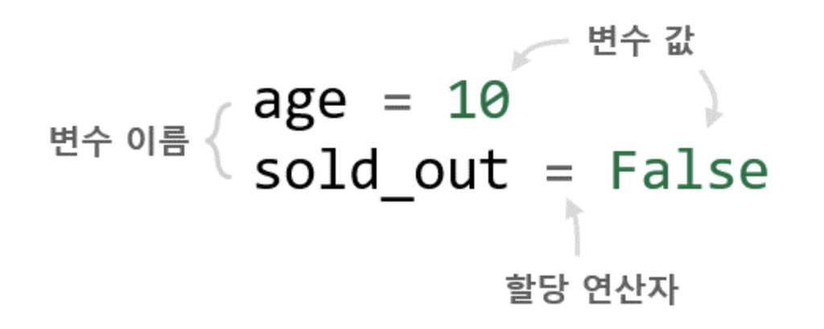

```python
Image("./이미지/할당문.png", width=500, height=500)
```

### 두 정수를 더한 결과가 계산되어 변수에 할당된다

```python
var = 1 + 5
```

## 분기문과 반복문에 주요 예약어

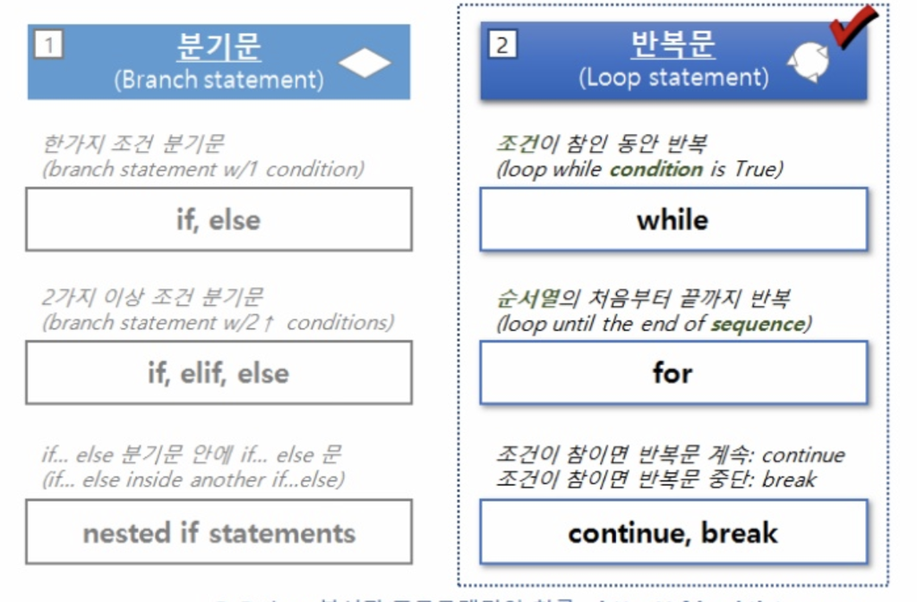

```python
Image("./이미지/분기문과반복문.png", width=500, height=500)
```

## 2-3 분기문

- 특정 조건이 있을 때 수행하는 로직을 분리

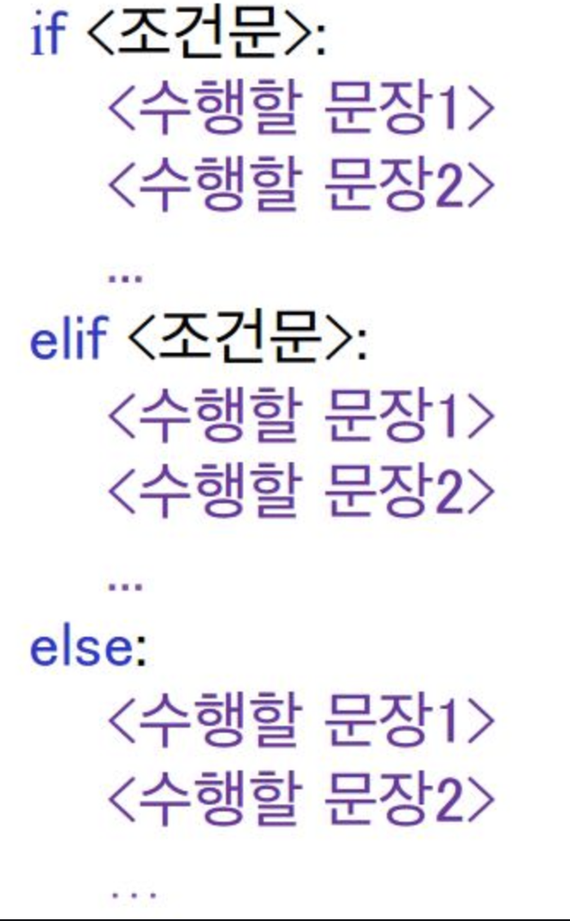

```python
Image("./이미지/제어문.png", width=200, height=200)
```

### 논리식 알아보기

- 특정 조건을 참(True) 또는 거짓(False)로 판단하기

#### 논리식을 지정해서 bool로 확인하기

```python
bool(100 > 10)
```

```
True
```

```python
100 > 10
```

```
True
```

#### 0을 논리식으로 확인하면 False 가 나온다

- 없다는 의미일 경우는 전부 거짓으로 인식한다

```python
bool(0),  bool(1)
```

```
(False, True)
```

### 단순 제어문

- if 문을 하나만 사용하기

```python
if True :
    print(" 참인 조건을 처리하기")
```

```
 참인 조건을 처리하기
```

```python
if 100 > 10 :
    print(" 100은 10보다 크다 ")
```

```
 100은 10보다 크다
```

### 복합 제어문

- if 문과 elif, else 문을 사용
- 조건이 여러 개가 있을 경우 elif 문을 추가
- 또한 마지막에 조건이 없을 경우 else 문 사용

```python
if 10 > 100 :
    print(" a ")
elif 10 < 100 :
    print('b')
```

```
b
```

## 2-4 순환문 알아보기

- 여러 번 반복해서 같은 로직을 처리할 때 사용
- 순환은 반복되는 객체를 사용하는 for 문과 특정 조건을 만족할 때 종료하는 while 문

### for 순환문

- 여러 개의 원소를 가진 객체를 in 다음에 표시한다.
- 정수 등을 지정할 경우는 하나의 원소만을 가지므로 예외가 발생한다

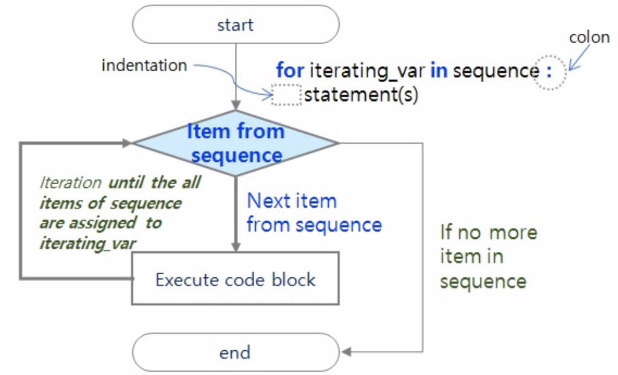

```python
Image("./이미지/반복문for.png", width=500, height=500)
```

#### 반복되는 객체 만들기

```python
type(range)
```

```
type
```

```python
range(5).__class__
```

```
range
```

#### 순환문 작성하기

```python
for i in range(5) :
    print(" 순환 알아보기", i)
```

```
 순환 알아보기 0
 순환 알아보기 1
 순환 알아보기 2
 순환 알아보기 3
 순환 알아보기 4
```

```python
for j in 5 :
    print(" 순환 알아보기", i)
```

```
---------------------------------------------------------------------------
TypeError                                 Traceback (most recent call last)
<ipython-input-15-196e24e80a6d> in <module>
----> 1 for j in 5 :
      2     print(" 순환 알아보기", i)

TypeError: 'int' object is not iterable
```

### while 순환문

- 특정 조건을 만족할 때까지 반복한다.
- 조건이 항상 참일 경우는 무한반복을 할 수 있다

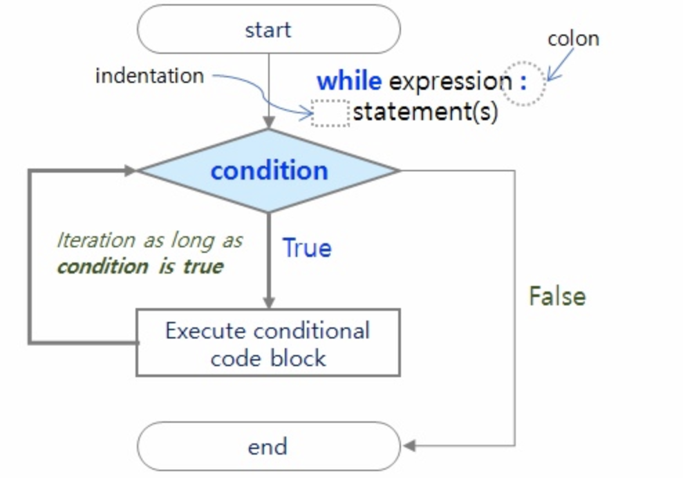

```python
Image("./이미지/반복문while.png", width=500, height=500)
```

#### 특정 변수의 값이 5보다 작을 경우

```python
i = 0
```

```python
while i < 5 :
    print(" 순환 알아보기", i)
    i = i + 1
```

```
 순환 알아보기 0
 순환 알아보기 1
 순환 알아보기 2
 순환 알아보기 3
 순환 알아보기 4
```